# White wine quality exploration by Chomnoue Nghemning Alain-Michel

# Final Plots and Summary

### Plot One

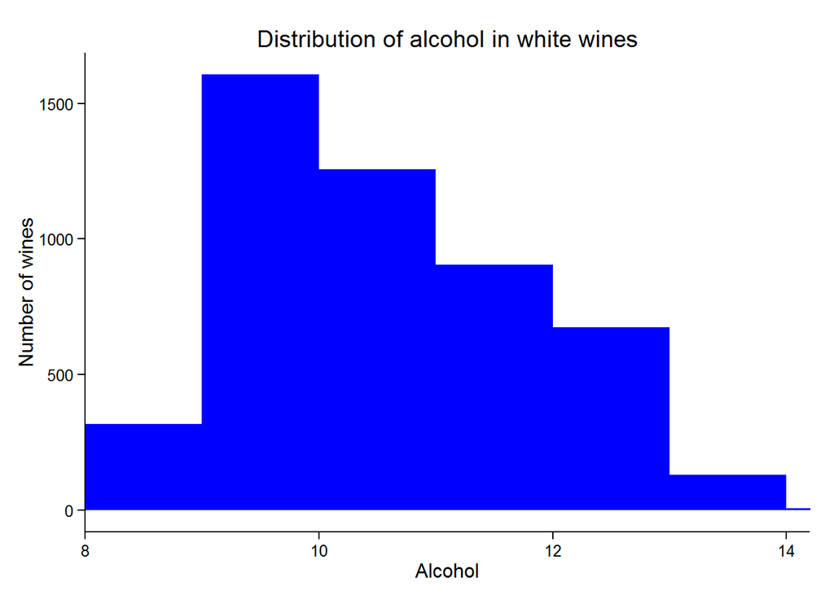

```r
alcohol.plot+
  xlab("Alcohol")+
  ylab("Number of wines")
```

### Description One

We have few wines with alcohol rate between 8 and 9. The peak of frequency is betwhen 9 an 10. The frequency then decreases with alcohol growing up to 14. Most values are between 9 and 12. Alcohol is one of the variables(with residual sugar and quality)that does not seem to be normally distributed

### Plot Two

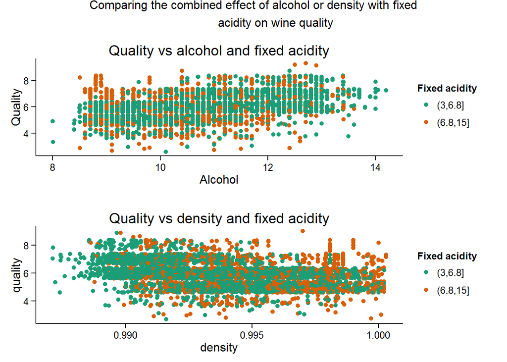

```r
title="Comparing the combined effect of alcohol or density with fixed
             acidity on wine quality"
grid.arrange(quality.alcohol.fixed.acidity.plot,
             quality.density.fixed.acidity.plot,
             ncol=1, main=title)
```

### Description Two

Most of the wines of high quality and low alcohol, as well as those of high quality and high density are of high fixed acidity. This is consistant with the correlation between alcohol and density.

### Plot Three

[output not shown]

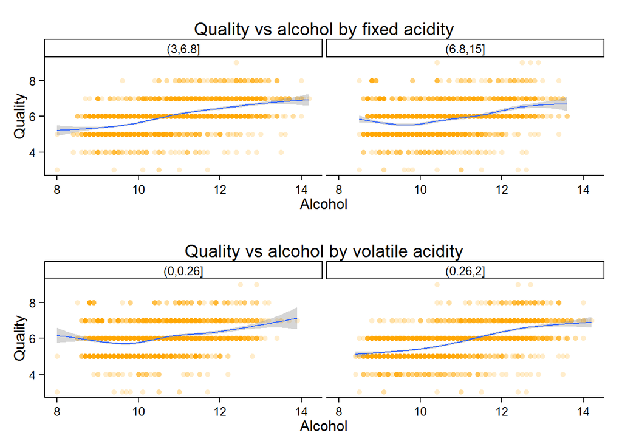

```r
grid.arrange(quality.alcohol.by.fixed.acidity.plot,
             quality.alcohol.by.volatile.acidity.plot,ncol=1)
```

### Description Three

The increase of wine quality with alcohol seems more evident for lower values of fixed acidity and higher values of volatile acidity.

# Reflection

My exploration of the white whines data set revealed some interesting findings.The data is made of 4898 entries, each one having 11 chemical properties of a white wine and the quality, as the output attribute, graded by wine experts.All the attibutes ara numerical.

After summarising the data, I went through individual attributes to understand their distributions and I found that most of them seemed to be normally distributed. Going through pair relationships, I found two pairs of highly correlated attritutes, namely “Density-Alchohol” and “Residual sugar-Alcohol”. It may not be interesting to use them together when building a model.

Plotting them against wine quality (with a smooth curve to help me see trends) I found that the output variable is mainly influenced (positively or negatively) by alcohol, pH, fixed acidity, volatile acidity, and density. I then went through some combinations of theses variables to undersdant how they relate to wine quality. Since they were all numerical, I first started with a heat map, but it appears difficult for me to have insight from that. I then transformed some of the variables by dividing them into two buckets around their medians and this helped me to gain more findings.

I unfortunately have not found any linear (or near linear) relationship between wine quality and any attribute, combination or transformation of attributes, so I preffered not to build a linear model for now. I thing that several model types should be considered and compared to have the best prediction of wine quality. Let me take the “Intro to Machine Learning” course before reworking on this!